# Reproducible_Research_Course_Project_1

Sandeep Muttha

May 23, 2017

Load required libraries

```r
library(dplyr)
library(ggplot2)
```

## 1. Loading and preprocessing the data

Code for reading in the dataset and/or processing the data

```r
download.file("https://d396qusza40orc.cloudfront.net/repdata%2Fdata%2Factivity.zip", destfile = "data.zip")
activity <- read.csv(unzip("data.zip"))

steps_per_day <- activity %>%
    group_by(date) %>%
    summarise(sum_steps = sum(steps, na.rm = TRUE))
```

## 2. What is mean total number of steps taken per day?

Histogram of the total number of steps taken each day

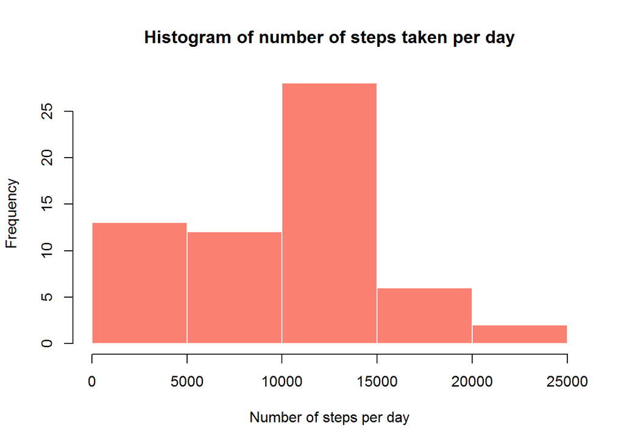

```r
hist(steps_per_day$sum_steps, col = "salmon", border = "white", main = "Histogram of number of steps taken per day", xlab = "Number of steps per day")
```

Mean and median number of steps taken each day

```r
mean_steps_per_day <- mean(steps_per_day$sum_steps)
median_steps_per_day <- median(steps_per_day$sum_steps)
```

Mean number of steps taken per day over the period of analysis is 9354  
Median number of steps taken per day over the period of analysis is 10395

## 3. What is the average daily activity pattern?

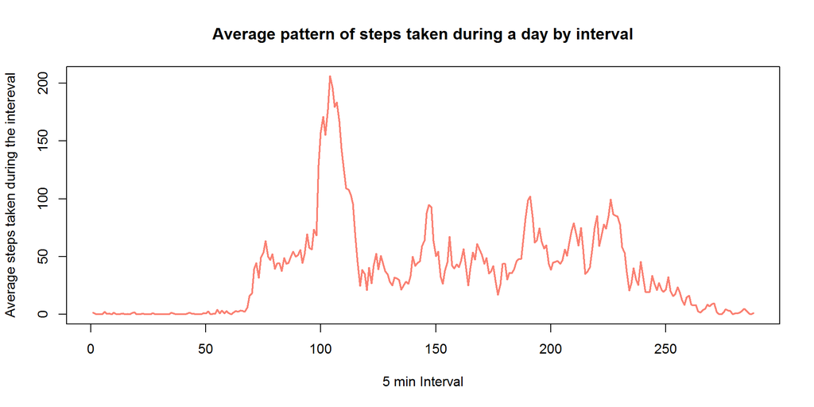

```r
avg_steps_in_interval <- activity %>%
    group_by(interval) %>%
    summarise(mean_steps = mean(steps, na.rm = TRUE))

plot(avg_steps_in_interval$mean_steps, type = "l", xlab = "5 min Interval", ylab = "Average steps taken during the intereval", main = "Average pattern of steps taken during a day by interval", lwd = 2, col = "salmon")
```

```r
max_step_interval <- which.max(avg_steps_in_interval$mean_steps)
```

5 minute Interval “104” on average across all the days in the dataset, contains the maximum number of steps.

## 4. Imputing missing values

Check for rows with missing data

```r
count_missing <- sum(!complete.cases(activity))
imputed_activity <- transform(activity,
                          steps = ifelse(is.na(activity$steps), avg_steps_in_interval$mean_steps[match(activity$interval, avg_steps_in_interval$interval)], activity$steps))
```

Number of records with missing data is 2304

Missing values were imputed with average values for that interval across all days.

Replotting histogram of total steps by day and recalculating mean and median steps per day

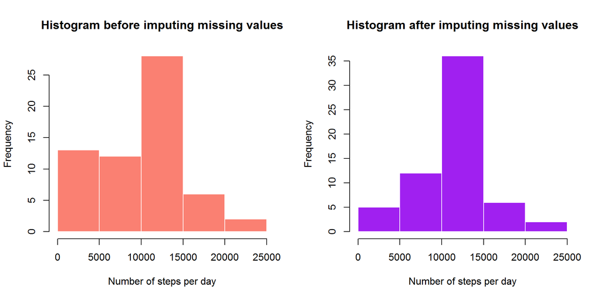

```r
steps_per_day_new <- imputed_activity %>%
    group_by(date) %>%
    summarise(sum_steps = sum(steps, na.rm = TRUE))

par(mfrow = c(1,2))

hist(steps_per_day$sum_steps, col = "salmon", border = "white", main = "Histogram before imputing missing values", xlab = "Number of steps per day")

hist(steps_per_day_new$sum_steps, col = "purple", border = "white", main = "Histogram after imputing missing values", xlab = "Number of steps per day")
```

Mean and median number of steps taken each day recalculated after imputing missing values

```r
mean_steps_per_day_new <- mean(steps_per_day_new$sum_steps)
median_steps_per_day_new <- median(steps_per_day_new$sum_steps)
```

Mean number of steps taken per day over the period of analysis is 10766 which is an increase of 1412 after imputation.  
Median number of steps taken per day over the period of analysis is 10766 which is an increase of 371 after imputation.

## 5. Are there differences in activity patterns between weekdays and weekends?

Creating a factor variable to classify weekdays and weekends and compute means in each interval comparing weekdays and weekends.

```r
imputed_activity$weekday <- as.factor(ifelse(is.element(weekdays(as.Date(imputed_activity$date)), c("Saturday", "Sunday")), "weekend", "weekday"))

avg_steps_in_interval_new <- imputed_activity %>%
    group_by(interval, weekday) %>%
    summarise(mean_steps = mean(steps, na.rm = TRUE))
```

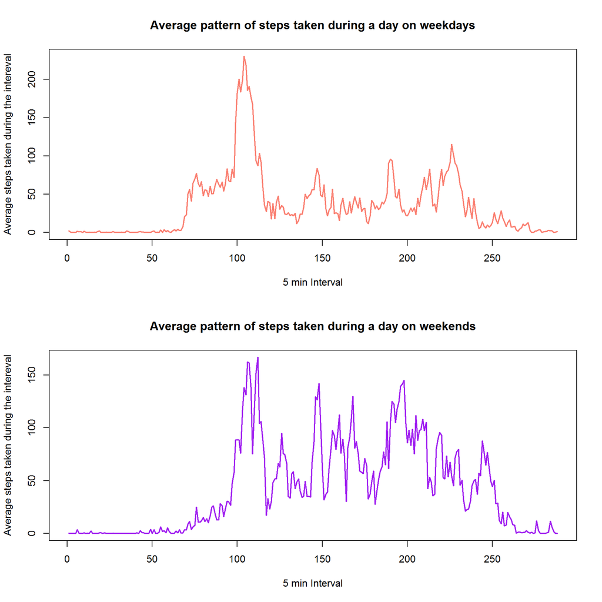

```r
par(mfrow = c(2,1))

plot(avg_steps_in_interval_new[avg_steps_in_interval_new$weekday == "weekday",]$mean_steps, type = "l", xlab = "5 min Interval", ylab = "Average steps taken during the intereval", main = "Average pattern of steps taken during a day on weekdays", lwd = 2, col = "salmon")

plot(avg_steps_in_interval_new[avg_steps_in_interval_new$weekday == "weekend",]$mean_steps, type = "l", xlab = "5 min Interval", ylab = "Average steps taken during the intereval", main = "Average pattern of steps taken during a day on weekends", lwd = 2, col = "purple")
```